# DE DAS and DTU analysis

13 January, 2025

To use our pipeline in your work, please cite:

- Guo,W., Tzioutziou,N., Stephen,G., Milne,I., Calixto,C., Waugh,R., Brown,J.W., and Zhang,R. (2019) 3D RNA-seq - a powerful and flexible tool for rapid and accurate differential expression and alternative splicing analysis of RNA-seq data for biologists. bioRxiv, 656686. doi: https://doi.org/10.1101/656686.
- Calixto,C.P.G., Guo,W., James,A.B., Tzioutziou,N.A., Entizne,J.C., Panter,P.E., Knight,H., Nimmo,H.G., Zhang,R., and Brown,J.W.S. (2018) Rapid and Dynamic Alternative Splicing Impacts the Arabidopsis Cold Response Transcriptome. Plant Cell, 30, 1424–1444.

## Method

The 3D RNA-seq App was developed for rapid and accurate differential expression (DE), differential alternative splicing (DAS) gene and differential transcript usage (DTU) (3D) analysis (Guo et al., 2019; Calixto et al., 2018).

### RNA-seq datasets

The RNA-seq data had 20 factor groups (SETI_WT.mock, SETI_e.mock, SETI_p.mock, SETI_s.mock, SETI_ps.mock, SETI_WT.P, SETI_e.P, SETI_p.P, SETI_s.P, SETI_ps.P, SETI_WT.E, SETI_e.E, SETI_p.E, SETI_s.E, SETI_ps.E, SETI_WT.PE, SETI_e.PE, SETI_p.PE, SETI_s.PE, SETI_ps.PE) and each had 3 biological replicates (60 samples in total).

### DE, DAS and DTU analysis

The pipeline of limma R package was used for 3D expression comparison (Ritchie et al., 2015; Law et al., 2014). To compare the expression changes between conditions of experimental design, the contrast groups were set as SETI_WT.P-SETI_WT.mock, SETI_WT.E-SETI_WT.mock, SETI_WT.PE-SETI_WT.mock, SETI_e.P-SETI_e.mock, SETI_e.E-SETI_e.mock, SETI_e.PE-SETI_e.mock, SETI_p.P-SETI_p.mock, SETI_p.E-SETI_p.mock, SETI_p.PE-SETI_p.mock, SETI_s.P-SETI_s.mock, SETI_s.E-SETI_s.mock, SETI_s.PE-SETI_s.mock, SETI_ps.P-SETI_ps.mock, SETI_ps.E-SETI_ps.mock, SETI_ps.PE-SETI_ps.mock. For DE genes/transcripts, the $log_2$ fold change ($L_2FC$) of gene/transcript abundance were calculated based on contrast groups and significance of expression changes were determined using t-test (Figure 1). P-values of multiple testing were adjusted with BH to correct false discovery rate (FDR) (Benjamini and Yekutieli, 2001). A gene/transcript was significantly DE in a contrast group if it had adjusted p-value < 0.01 and $L_2FC$ $\geq$ 1.

At the alternative splicing level, DTU transcripts were determined by comparing the $L_2FC$ of a transcript to the weighted average of $L_2FCs$ (weights were based on their standard deviation) of all remaining transcripts in the same gene. A transcript was determined as significant DTU if it had adjusted p-value < 0.01 and $\Delta$PS $\geq$ 0.1 (Figure 1). For DAS genes, each individual transcript $L_2FC$ were compared to gene level $L_2FC$, which was calculated as the weighted average of $L_2FCs$ of all transcripts of the gene. Then p-values of individual transcript comparison were summarised to a single gene level p-value with F-test. A gene was significantly DAS in a contrast group if it had an adjusted p-value < 0.01 and any of its transcript had a $\Delta$ Percent Spliced ($\Delta$PS) ratio $\geq$ 0.1 (Figure 1).

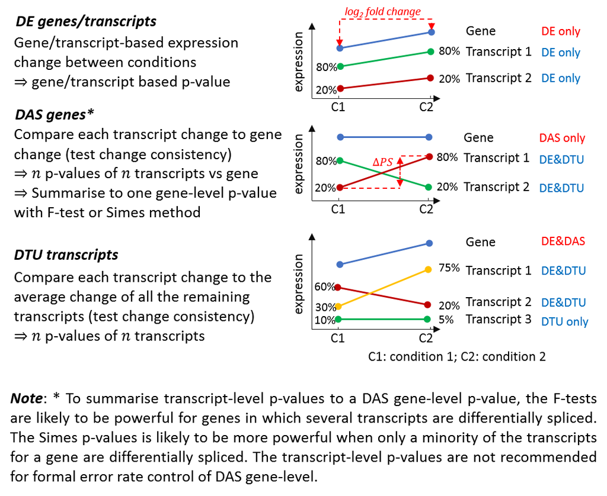

**Figure 1**: Testing of DE genes, DAS genes, DE transcripts and DTU transcripts.

### Isoform switch analysis

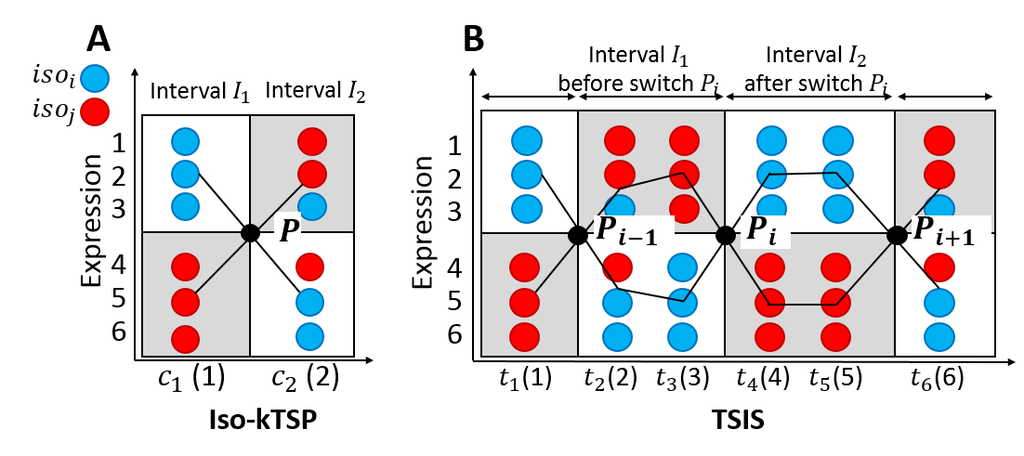

[output not shown]

[output not shown]

**Figure 2**: Isoform switch analysis methods. Expression data with 3 replicates for each condition/time-point is simulated for isoforms $iso_{i}$ and $iso_j$ (blue and red circles). The points in the plots represent data samples and the black lines connect the average of samples. (A) is the Pair-Wise Isoform Switch (isokTSP) method for comparisons of two conditions $c_1$ and $c_2$ (e.g. conditions in contrast groups of 3D RNA-seq analysis). The Time-Series Isoform Switch (TSIS) tool is designed for detection and characterization of isoform switches for time series data shown in (B). The time-series with 6 time-points is divided into 4 intervals by the intersection points of average expression. If the conditions/time-points on x-axis are not numeric, they will be converted to numeric coordinates 1, 2, 3, ... to fit the lines.

## Results

### RNA-seq data variation

[output not shown]

[output not shown]

### Number of transcripts per gene

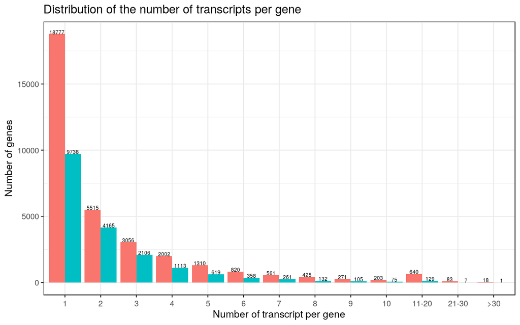

Figure: Distribution of the number of transcripts per gene. Low expressed transcripts and genes are filtered.

### Number of 3D genes and transcripts

RNA-seq sample information before and after data pre-processing.

| Description | Number |
| --- | --- |
| Raw transcripts | 81620 |
| Raw genes | 33681 |
| Samples | 60 |
| Samples after merging seq-reps | 60 |
| Condition of interest | 20 |
| CPM cut-off | 1 |
| Min samples to CPM cut-off | 3 |
| Expressed transcripts | 40568 |
| Expressed genes | 18809 |

Number of DE/DAS genes and DE/DTU transcripts in different contrast groups.

| contrast | DE genes | DAS genes | DE transcripts | DTU transcripts |
| --- | --- | --- | --- | --- |
| SETI_WT.P-SETI_WT.mock | 7212 | 110 | 8094 | 143 |
| SETI_WT.E-SETI_WT.mock | 2159 | 66 | 2424 | 88 |
| SETI_WT.PE-SETI_WT.mock | 5938 | 81 | 6312 | 114 |
| SETI_e.P-SETI_e.mock | 9158 | 196 | 11069 | 243 |
| SETI_e.E-SETI_e.mock | 0 | 25 | 4 | 16 |
| SETI_e.PE-SETI_e.mock | 8962 | 194 | 10724 | 281 |
| SETI_p.P-SETI_p.mock | 8851 | 156 | 10368 | 212 |
| SETI_p.E-SETI_p.mock | 1374 | 29 | 1304 | 38 |
| SETI_p.PE-SETI_p.mock | 8960 | 172 | 10497 | 244 |
| SETI_s.P-SETI_s.mock | 8961 | 171 | 10577 | 200 |
| SETI_s.E-SETI_s.mock | 2959 | 88 | 3089 | 126 |
| SETI_s.PE-SETI_s.mock | 8349 | 154 | 9629 | 240 |
| SETI_ps.P-SETI_ps.mock | 8243 | 153 | 9533 | 189 |
| SETI_ps.E-SETI_ps.mock | 0 | 19 | 2 | 14 |
| SETI_ps.PE-SETI_ps.mock | 8771 | 155 | 10242 | 217 |

Number of DE vs DAS genes.

| Contrast | DEonly | DE&DAS | DASonly |
| --- | --- | --- | --- |
| SETI_WT.P-SETI_WT.mock | 7147 | 65 | 45 |
| SETI_WT.E-SETI_WT.mock | 2138 | 21 | 45 |
| SETI_WT.PE-SETI_WT.mock | 5899 | 39 | 42 |
| SETI_e.P-SETI_e.mock | 9035 | 123 | 73 |
| SETI_e.E-SETI_e.mock | 0 | 0 | 25 |
| SETI_e.PE-SETI_e.mock | 8842 | 120 | 74 |
| SETI_p.P-SETI_p.mock | 8753 | 98 | 58 |
| SETI_p.E-SETI_p.mock | 1370 | 4 | 25 |
| SETI_p.PE-SETI_p.mock | 8851 | 109 | 63 |
| SETI_s.P-SETI_s.mock | 8854 | 107 | 64 |
| SETI_s.E-SETI_s.mock | 2929 | 30 | 58 |
| SETI_s.PE-SETI_s.mock | 8259 | 90 | 64 |
| SETI_ps.P-SETI_ps.mock | 8151 | 92 | 61 |
| SETI_ps.E-SETI_ps.mock | 0 | 0 | 19 |
| SETI_ps.PE-SETI_ps.mock | 8666 | 105 | 50 |

Number of DE vs DTU transcripts.

| Contrast | DEonly | DE&DTU | DTUonly |
| --- | --- | --- | --- |
| SETI_WT.P-SETI_WT.mock | 8003 | 91 | 52 |
| SETI_WT.E-SETI_WT.mock | 2381 | 43 | 45 |
| SETI_WT.PE-SETI_WT.mock | 6240 | 72 | 42 |
| SETI_e.P-SETI_e.mock | 10903 | 166 | 77 |
| SETI_e.E-SETI_e.mock | 2 | 2 | 14 |
| SETI_e.PE-SETI_e.mock | 10539 | 185 | 96 |
| SETI_p.P-SETI_p.mock | 10233 | 135 | 77 |
| SETI_p.E-SETI_p.mock | 1289 | 15 | 23 |
| SETI_p.PE-SETI_p.mock | 10352 | 145 | 99 |
| SETI_s.P-SETI_s.mock | 10441 | 136 | 64 |
| SETI_s.E-SETI_s.mock | 3024 | 65 | 61 |
| SETI_s.PE-SETI_s.mock | 9481 | 148 | 92 |
| SETI_ps.P-SETI_ps.mock | 9417 | 116 | 73 |
| SETI_ps.E-SETI_ps.mock | 2 | 0 | 14 |
| SETI_ps.PE-SETI_ps.mock | 10105 | 137 | 80 |

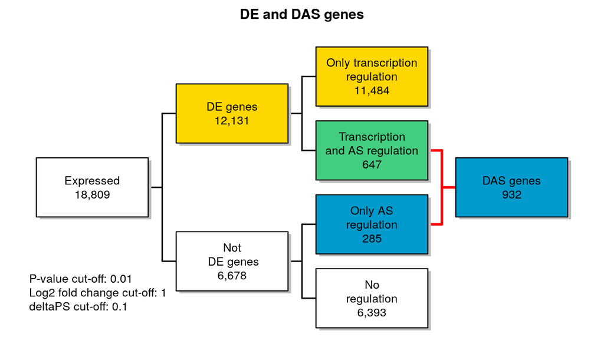

Figure: Number of genes regulated only by transcription (DE), only by alternative splicing (DAS) and by both transcription and alternative splicing (DE+DAS).

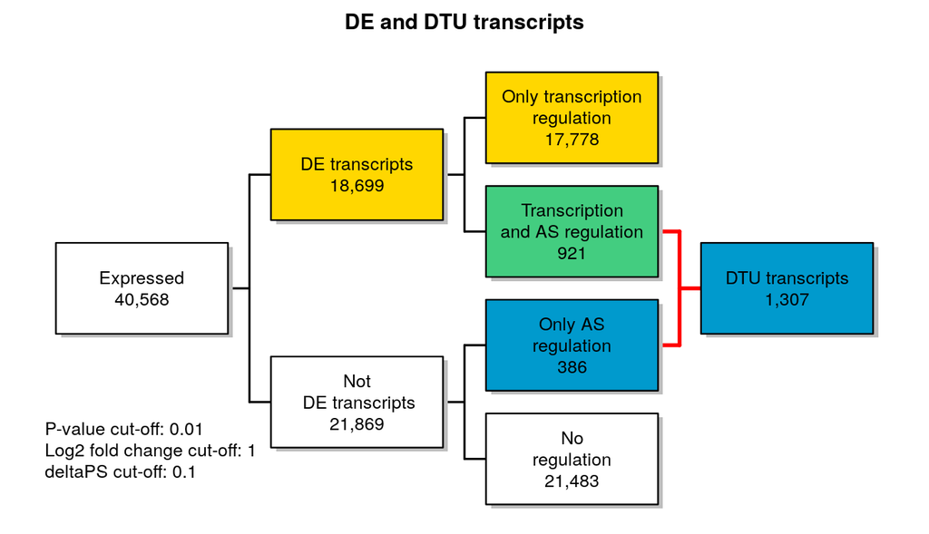

[output not shown]

### Up- and down-regulation

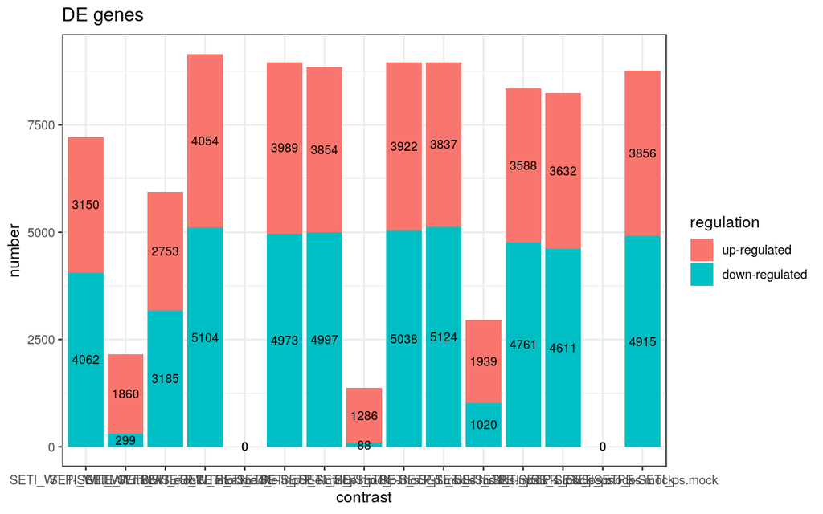

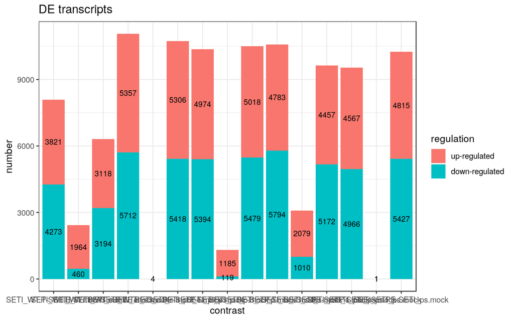

### Volcano plot

Figure: Volcano plot. The low expressed genes and transcripts were filtered. DE genes: log2FC vs -log10(FDR) at gene level; DAS genes: maximum $\Delta PS$ of transcript in a gene vs -log10(FDR) at gene level; DE transcripts: log2FC vs -log10(FDR) at gene level at transcript level and DTU transcripts: $\Delta PS$ vs -log10(FDR) at transcript level.

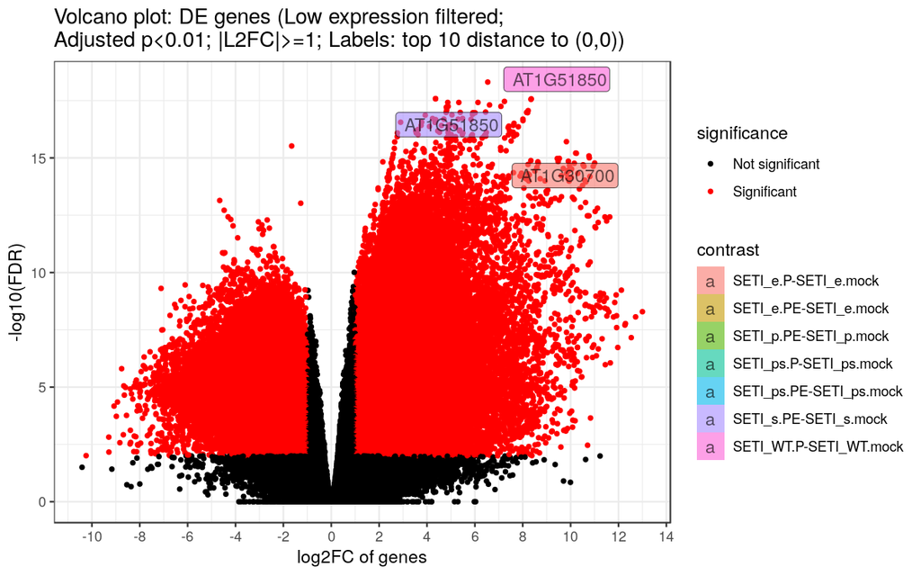

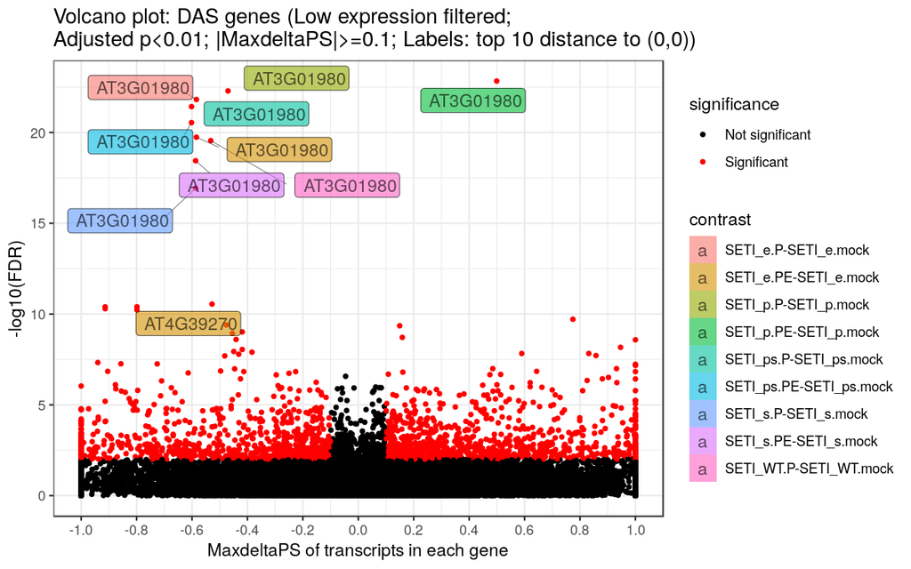

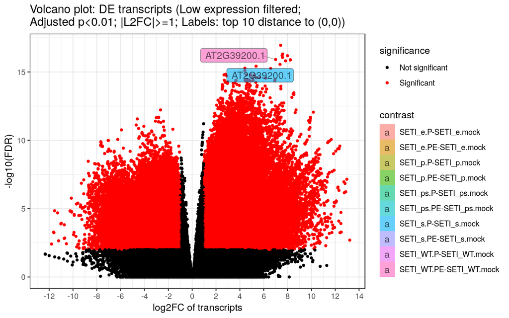

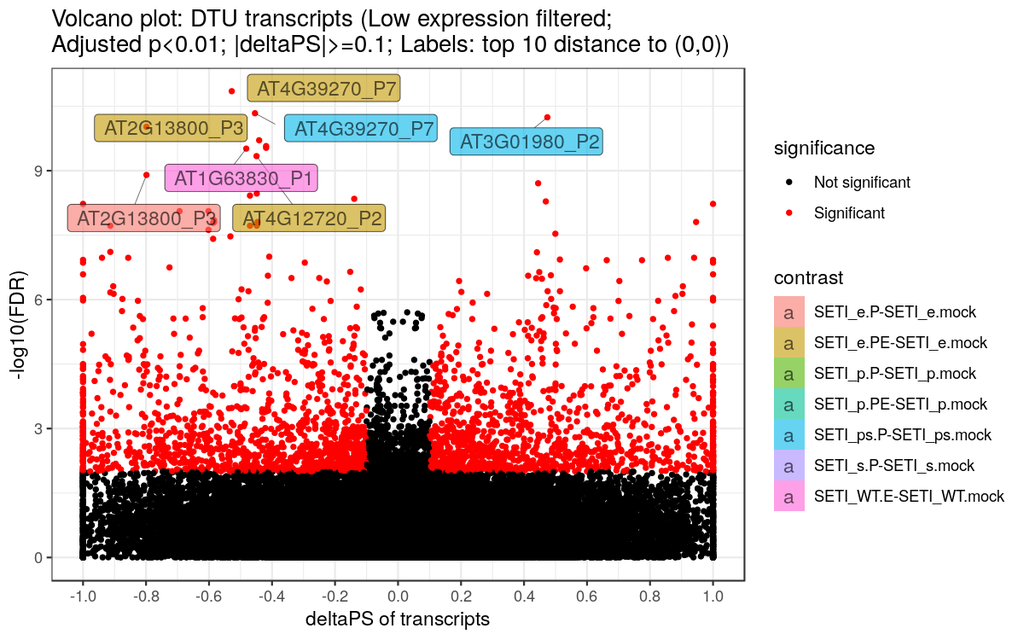

### Heatmap

Hierarchical clustering was used to partition the DE genes into 10 clusters with euclidean distance and ward.D clustering algorithm (Saracli et al., 2013). ComplexHeatmap R package version 1.20.0 was used to make the heat-maps.

Figure: Heatmap of DE genes, including DE only and DE+DAS genes.

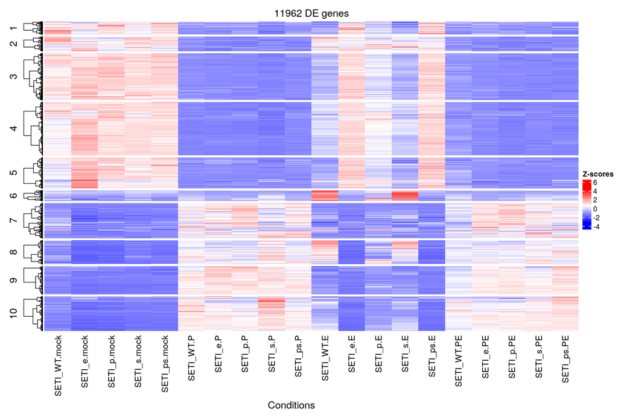

[output not shown]

[output not shown]

[output not shown]

### GO annotation plot

Figure: Significant GO enriched terms of DE genes.

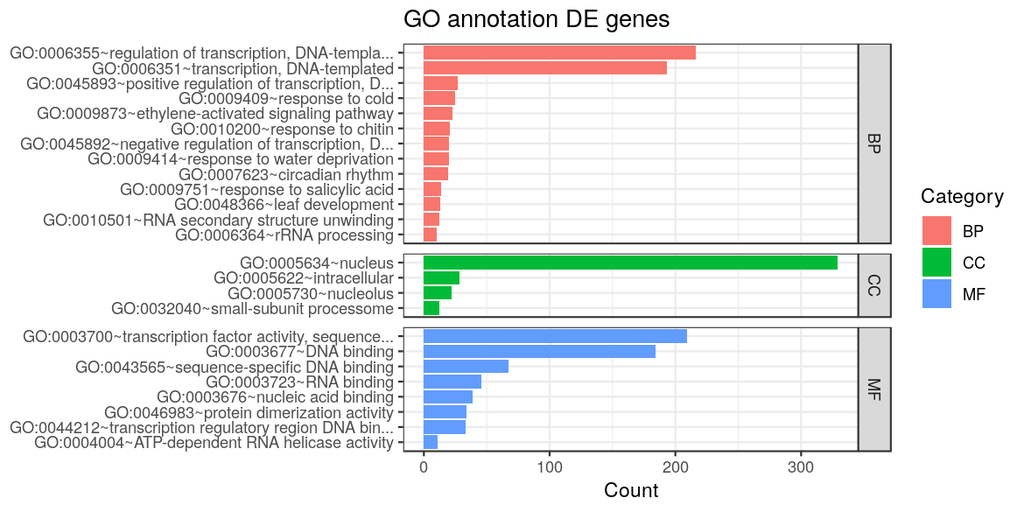

[output not shown]

### Significant isoform switches

Figure: Significant isoform switches between transcript isoforms.

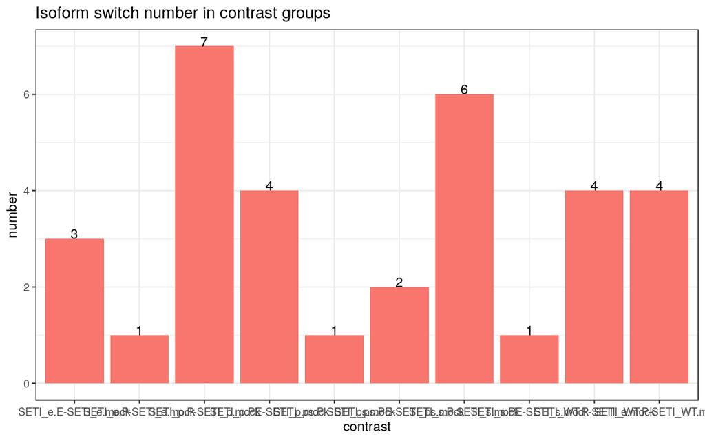

## Supplementary figures

### Mean-variance trend plot

The cut-offs to filter the transcripts were determined by the mean-variance trend plots (Law et al. 2014).

Figure: Transcript level mean-variance trend plot

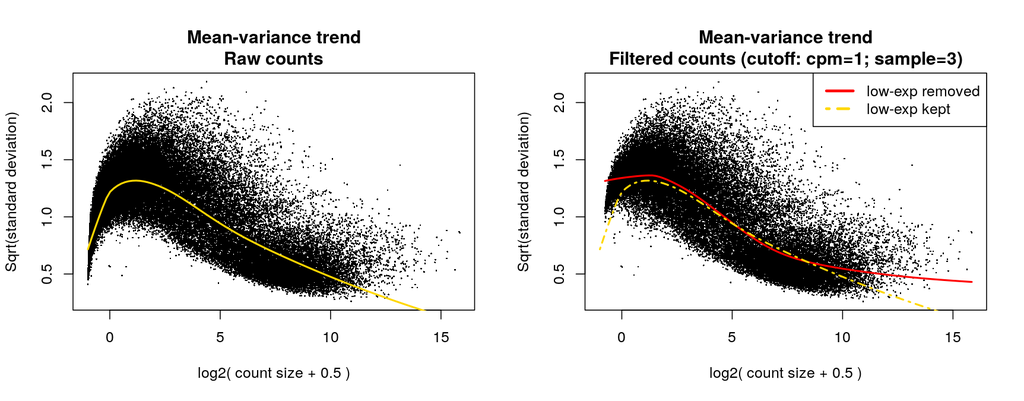

Figure: Gene level mean-variance trend plot

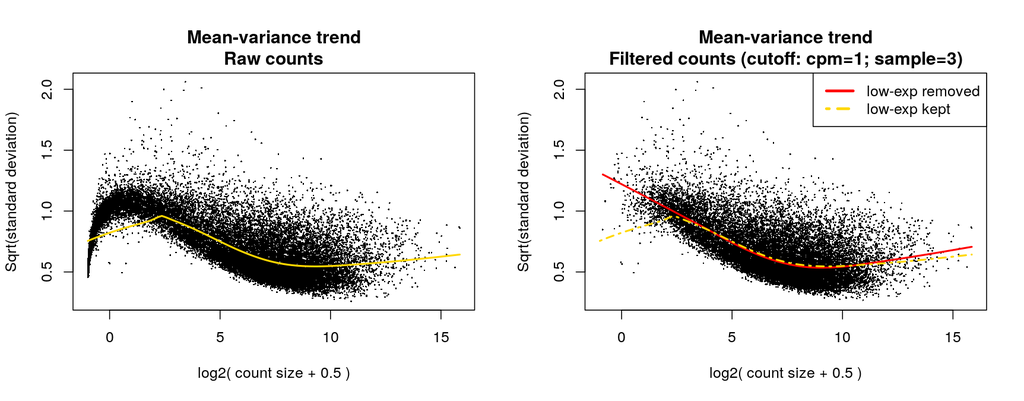

### PCA plot of all samples

The normalised $log_2$-CPM of all samples were used to make PCA plots. The PCA plot of all samples can be found in the figure folder.

### Sample distribution

Figure: Transcript level read counts and normalised $log_2$-CPM distribution across samples.

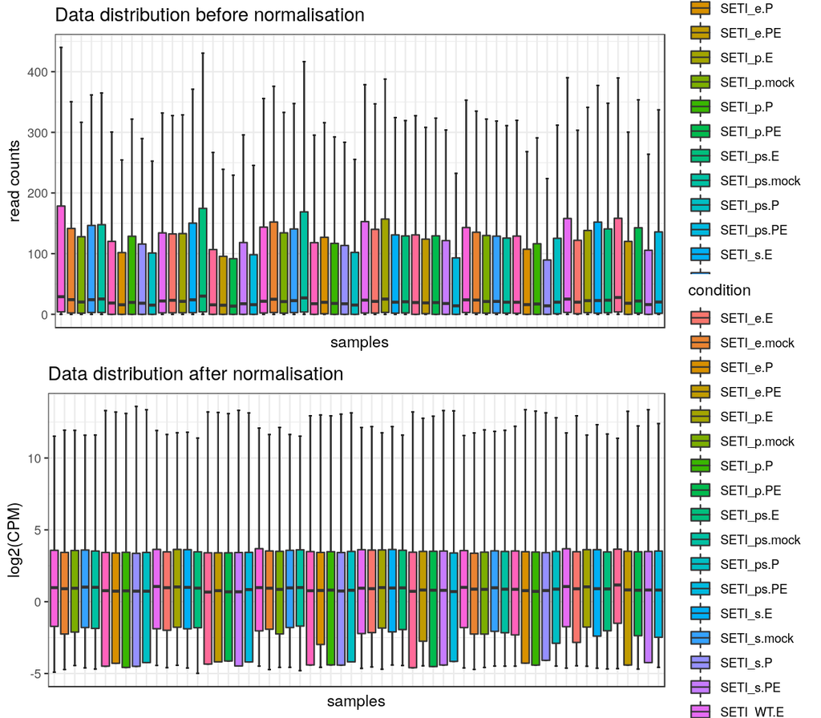

Figure: Gene level read counts and normalised $log_2$-CPM distribution across samples.

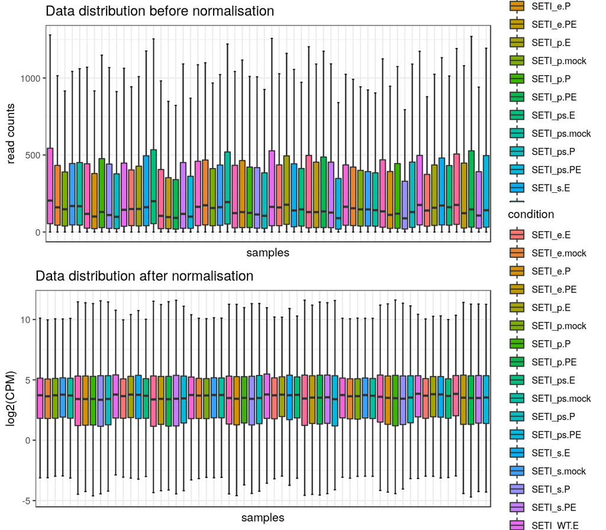

### Venn diagrams

Venn diagrams to compare significant DE genes, DAS genes, DE transcript and DTU transcripts in different contrast groups can be found in figure folder.

## Supplementary materials

### Files in report folder

Reports are saved in report folder.

| File name | Description |
| --- | --- |
| 3D_report.pdf/html/doc | Report of 3D analysis in pdf, html and doc format |

### Files in figure folder

| File.names | Description |
| --- | --- |
| DAS genes GO annotation plot.png/.pdf | DAS genes GO annotation plot |
| DAS genes updown regulation numbers.png/.pdf | DAS genes up-down regulation numbers |
| DAS genes volcano plot.png/.pdf | DAS genes volcano plot |
| DE genes GO annotation plot.png/.pdf | DE genes GO annotation plot |
| DE genes updown regulation numbers.png/.pdf | DE genes up-down regulation numbers |
| DE genes volcano plot.png/.pdf | DE genes volcano plot |
| DE transcripts updown regulation numbers.png/.pdf | DE transcripts up-down regulation numbers |
| DE transcripts volcano plot.png/.pdf | DE transcripts volcano plot |
| DTU transcripts updown regulation numbers.png/.pdf | DTU transcripts up-down regulation numbers |
| DTU transcripts volcano plot.png/.pdf | DTU transcripts volcano plot |
| Gene data distribution.png/.pdf | Gene data distribution |
| Gene mean-variance trend.png/.pdf | Gene mean-variance trend |
| Gene PCA Average expression.png/.pdf | Gene PCA Average expression |
| Gene PCA batch effect removed Bio-reps.png/.pdf | Gene PCA batch effect removed Bio-reps |
| Gene PCA Bio-reps.png/.pdf | Gene PCA Bio-reps |
| Heatmap DAS genes.png/.pdf | Heatmap of DE+DAS genes |
| Heatmap DE genes.png/.pdf | Heatmap of DE genes |
| Heatmap DE transcripts.png/.pdf | Heatmap of DE transcripts |
| Heatmap DTU transcripts.png/.pdf | Heatmap of DE+DTU transcripts |
| Transcript data distribution.png/.pdf | Transcript data distribution |
| Transcript mean-variance trend.png/.pdf | Transcript mean-variance trend |
| Transcript PCA Average expression.png/.pdf | Transcript PCA Average expression |
| Transcript PCA batch effect removed Bio-reps.png/.pdf | Transcript PCA batch effect removed Bio-reps |
| Transcript PCA Bio-reps.png/.pdf | Transcript PCA Bio-reps |
| Union set DE genes vs DAS genes.png/.pdf | Flow chart -Union set DE genes vs DAS genes |
| Union set DE transcripts vs DTU transcripts.png/.pdf | Flow chart -Union set DE transcripts vs DTU transcripts |
| Isoform switch number.png/.pdf | Number of significant isoform switch numbers in contrast groups |

### Files in result folder

Important results are saved in csv (comma delimited) files.

[output not shown]

### Files in data folder

Intermediate data in .RData for 3D RAN-seq analysis are saved in the data folder. There are three .RData objects: 1) txi_trans.RData and 2) txi_genes.RData are transcript and gene level read count and TPM outputs from the tximport R package (Soneson et al., 2016). All the intermediate data generated in the process of 3D analysis is saved in the list object intermediate_data.RData. R users can access to the data using command line.

[output not shown]

## References

Benjamini,Y. and Yekutieli,D. (2001) The control of the false discovery rate in multiple testing under dependency. Ann. Stat., 29, 1165–1188.

Bray,N.L., Pimentel,H., Melsted,P., and Pachter,L. (2016) Near-optimal probabilistic RNA-seq quantification. Nat. Biotechnol., 34, 525–527.

Bullard,J.H., Purdom,E., Hansen,K.D., and Dudoit,S. (2010) Evaluation of statistical methods for normalization and differential expression in mRNA-Seq experiments. BMC Bioinformatics, 11, 94.

Calixto,C.P.G., Guo,W., James,A.B., Tzioutziou,N.A., Entizne,J.C., Panter,P.E., Knight,H., Nimmo,H., Zhang,R., and Brown,J.W.S. (2018) Rapid and dynamic alternative splicing impacts the Arabidopsis cold response transcriptome. Plant Cell, tpc.00177.2018.

Gu,Z., Eils,R., and Schlesner,M. (2016) Complex heatmaps reveal patterns and correlations in multidimensional genomic data. Bioinformatics, 32, 2847–2849.

Guo,W., Calixto,C.P.G., Brown,J.W.S., and Zhang,R. (2017) TSIS: An R package to infer alternative splicing isoform switches for time-series data. Bioinformatics, 33, 3308–3310.

Guo,W., Tzioutziou,N., Stephen,G., Milne,I., Calixto,C., Waugh,R., Brown,J.W., and Zhang,R. (2019) 3D RNA-seq - a powerful and flexible tool for rapid and accurate differential expression and alternative splicing analysis of RNA-seq data for biologists. bioRxiv, 656686. doi: https://doi.org/10.1101/656686.

Law,C.W., Chen,Y., Shi,W., and Smyth,G.K. (2014) voom: Precision weights unlock linear model analysis tools for RNA-seq read counts. Genome Biol, 15, R29.

Patro,R., Duggal,G., Love,M.I., Irizarry,R.A., and Kingsford,C. (2017) Salmon provides fast and bias-aware quantification of transcript expression. Nat. Methods, 14, 417–419.

Risso,D., Ngai,J., Speed,T.P., and Dudoit,S. (2014) Normalization of RNA-seq data using factor analysis of control genes or samples. Nat. Biotechnol., 32, 896–902.

Ritchie,M.E., Phipson,B., Wu,D., Hu,Y., Law,C.W., Shi,W., and Smyth,G.K. (2015) limma powers differential expression analyses for RNA-sequencing and microarray studies. Nucleic Acids Res, 43, e47.

Saraçli,S., Dogan,N., and Dogan,I. (2013) Comparison of hierarchical cluster analysis methods by cophenetic correlation. J. Inequalities Appl.

Soneson,C., Love,M.I., and Robinson,M.D. (2016) Differential analyses for RNA-seq: transcript-level estimates improve gene-level inferences. F1000Research, 4, 1521.